# Sample code to train maxent habitat model for a coral species

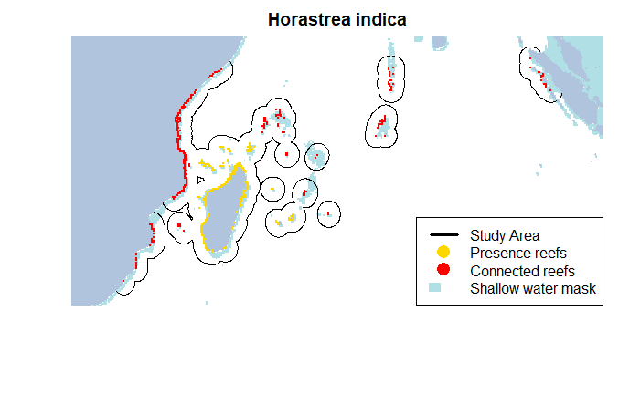

```r
#par(fig = c(0, 1, 0, 1), oma = c(0,0, 0, 0), mar = c(0, 0, 0, 0), new = TRUE, xpd=T)
#plot.new()
legend('bottomright',col=c('black','gold','red','powderblue'),pch=c(NA,16,16,NA),
       pt.cex=2, lty = c(1, NA, NA, NA), lwd=3,fill = c(NA, NA, NA, 'powderblue'), border = c(NA, NA, NA, 'powderblue'),
       legend = c('Study Area', 'Presence reefs', 'Connected reefs', 'Shallow water mask'), cex=1)
```

Writing the presence/absences and the environmental data used to train the MaxEnt models. Data will be saved in the same directory as the previously loaded data is in, in a subdirectory called “Horastrea.indica”:

```r
species = "Horastrea.indica"

# Creating output folder for the species:
dir.create(species)

# Restricting to study area:
env_data_species = ENV_DATA[study_area,]

# Applying shallow water mask:
env_data_species@data[is.na(env_data_species$Shallow_mask) | !env_data_species$Shallow_mask,] = NA

# Writing distribution data:
Presences_coords = coordinates(ENV_DATA)[which(ENV_DATA$cell_id %in% cells_species_present),]
distribution_data=data.frame(ID=species,X=Presences_coords[,1],Y=Presences_coords[,2])
write.csv(distribution_data, file = paste0(data_dir,'/',species,'/Presences.csv'), row.names = FALSE)

# Writing environmental data:
Env_var2use <- c("avg_depth", "highest_point", "K490_max", "K490_mean",
                 "K490_min", "NO3_max", "NO3_mean", "NO3_min", "O2_max",
                 "O2_mean", "O2_min", "PAR_max", "PAR_mean", "PAR_min",
                 "PO4_max", "PO4_mean", "PO4_min", "sal_max", "sal_mean",
                 "sal_min","SST_mean", "SST_max", "SST_min", "SST_SD",
                 "SST_range", "Dust", "Cyclone", "Irr_mean", "Irr_max",
                 "Irr_min", "Z_mean", "Z_max", "Z_min", "Speed_mean",
                 "Speed_max", "Speed_min", "UKESM_Aragonite_mean",
                 "UKESM_sal_mean", "UKESM_SST_mean")
for(vr in Env_var2use)
  write.asciigrid(env_data_species, fname=paste0(data_dir,"/",species,"/",vr,".asc"), attr = vr)
```

Generating background points within the study region, and extracting environmental data for presences and background points:

```r
# Read presences and convert to spatial:
presences <- read.csv(paste0(data_dir,"/",species,'/Presences.csv'))
presences <- SpatialPoints(presences[,c('X','Y')])

# Read environmental data and put it in SpatialGridDataFrame:
Env_data = as(stack(paste0(data_dir,"/",species,'/',Env_var2use,'.asc')),'SpatialGridDataFrame')

# 1) Missing data imputation (as the median within the study area):
Env_data$study_mask = !is.na(Env_data$SST_mean)
for(var in Env_var2use)
  Env_data[[var]][is.na(Env_data[[var]]) & Env_data$study_mask] = median(Env_data[[var]][Env_data$study_mask], na.rm = TRUE)
Env_data$study_mask=NULL
Env_data = as(Env_data,'SpatialPixelsDataFrame')

# 2) Choose randomly 10000 background points in the study region:
set.seed(3)
background = spsample(Env_data, n=10000, type='random')

# 3) Environmental data for presences and background points:
background = cbind(coordinates(background),over(background,Env_data))
names(background)[1:2]=c('X','Y')
presences = cbind(Species=species,coordinates(presences),over(presences,Env_data))
names(presences)[1:3]=c('Species','X','Y')

# 4) Getting rid of presences that fall outside study region:
presences = presences[complete.cases(presences),]

# 5) Saving presences and background data to file:
write.csv(background, row.names = F, file=paste0(data_dir,"/",species,'/Background_data.csv'))
write.csv(presences, row.names = F, file=paste0(data_dir,"/",species,'/Presences_data.csv'))
```

Training MaxEnt model using the R package “dismo”:

```r
# MaxEnt arguments:
MaxEnt_args=c("responsecurves", "betamultiplier=1", "jackknife", "replicates=1",
              "randomtestpoints=0", "doclamp", "maximumiterations=5000")

# Load presence and background data:
data.train <- read.csv(paste0(data_dir,"/",species,"/Presences_data.csv"), header=TRUE)
backgr <- read.csv(paste0(data_dir,"/",species,"/Background_data.csv"), header=TRUE)

# Combine presences and background points in one dataframe:
x <- rbind(data.train[,Env_var2use], backgr[,Env_var2use])

# Create vector containing 1 for presences and 0 for background) values to indicate which records are which
P <- c(rep(1,times=dim(data.train)[1]), rep(0,times=dim(backgr)[1]))

# Training MaxEnt model:
model_output_folder =  paste0(data_dir,"/",species,'/MaxEnt_model_',species,'_clamping')
dir.create(model_output_folder)
maxent_mod <- maxent(x=x, p=P, args=MaxEnt_args, removeDuplicates=TRUE, path=model_output_folder)
```

Plotting all environmental variables used for model training (circa 1990s):

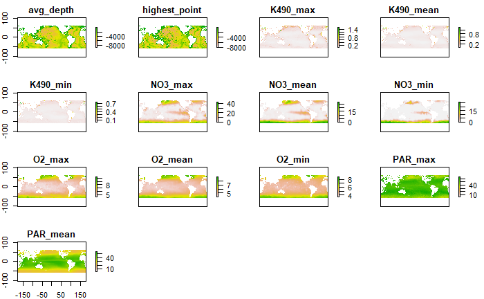

```r
env_training = stack(ENV_DATA[Env_var2use])
plot(subset(env_training, Env_var2use[1:13], drop=TRUE))
```

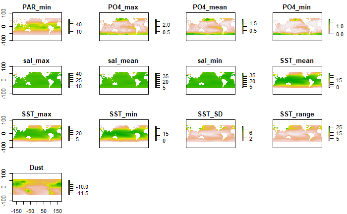

```r
plot(subset(env_training, Env_var2use[14:26], drop=TRUE))
```

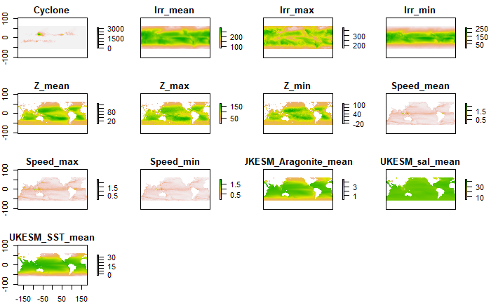

```r
plot(subset(env_training, Env_var2use[27:39], drop=TRUE))
```

Using the MaxEnt model to predict to training conditions: Note: At the time the work was carried out, the package “dismo” did not implement a way to use clamping in the predictions of a MaxEnt model. Therefore we used a workaround, calling MaxEnt directly from the windows terminal with all relevant arguments. This part of the code will likely need to be modified for operating systems other than windows.

```r
# Creating folder for the output:
pred_folder = paste0(model_output_folder,'/prediction_training')
dir.create(pred_folder)

# Since Horastrea indica is not one of the species we have classified as highly susceptible to bleaching, we project using clamping and constant-response

# Writing environmental data used by MaxEnt for the prediction:
writeRaster(env_training, filename=paste0(pred_folder, "\\", names(env_training)), format="ascii", bylayer=T, crs=T, overwrite=TRUE)

# Maxent arguments for the prediction:
output_file <- paste0(pred_folder, "\\Projection_training.asc")
ARGS_Clamp <- c(" doclamp=true outputformat=logistic writeclampgrid=true fadebyclamping=false") # arguments for the prediction
lambdas <- paste0(model_output_folder,'/species.lambdas') # Maxent model to use

# Path to MaxEnt java file 'maxent.jar':
maxent <- paste(system.file(package="dismo"), "/java/maxent.jar", sep='')

# System call to the MaxEnt java program:
invisible(system(paste0("java -mx1000m -cp \"", maxent, "\" density.Project \"", lambdas, "\" \"", pred_folder, "\" \"", output_file, "\" ", ARGS_Clamp)))
```

Plotting prediction and species study region:

```r
suitability  <- readAll(raster(output_file, native=F))
par(oma=c(0,0,0,0))
plot(study_area,main='Suitability for Horastrea indica, 1990s',col='white') # to set appropriate plot boundaries
plot(suitability,add=T)
```

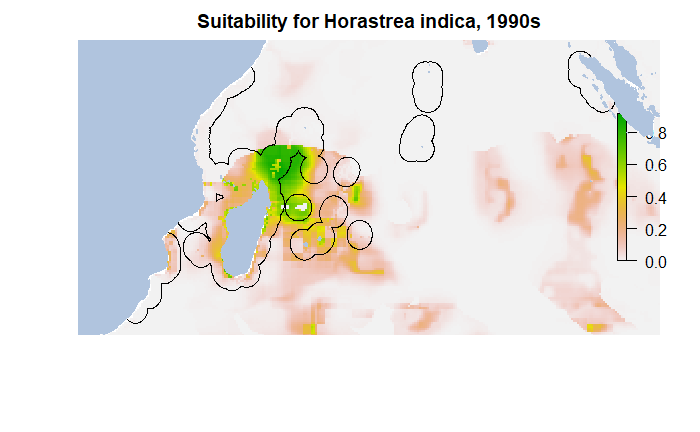

```r
plot(study_area,add=T)
plot(world,col='lightsteelblue',border='lightsteelblue',add=T)
```